# Aula 4 - NumPy e Pandas I

### 4.1.6 Indexação booleana

Também podemos realizar operações booleanas em arrays, de forma que o resultado será um novo array de valores booleanos, de acordo com a condição. Considere o exemplo:

```python
arr_string = np.array(["Dwight", "Michael", "Angela", "Oscar", "Michael", "Angela"])

# Condição : quais elementos do array são iguais a "Michael"?
arr_bool = arr_string == "Michael"
print(arr_bool)

# Condição : quais elementos do array são iguais a "Michael" OU "Angela"
arr_bool = (arr_string == "Michael") | (arr_string == "Angela")
print(arr_bool)
```

```
[False  True False False  True False]
[False  True  True False  True  True]
```

Também podemos fazer o processo reverso: passamos um array de booleanos para um array, e ele retorna somente os elementos (ou arrays) em que a condição é verdadeira:

```python
arr_string = np.array(["Dwight", "Michael", "Angela", "Oscar", "Michael", "Angela"])
arr_booleano = np.array([True,False,False,True,False,False])

# Seleciona somente os elementos em que arr_booleano == True
print(arr_string[arr_booleano])
```

```
['Dwight' 'Oscar']
```

Também podemos fazer a indexação booleana em arrays multidimensionais. Nesses casos as condições verdadeiras retornam arrays de dimensões menores. Considere o seguinte caso:

```python
# Gerando uma matriz 3x4 de aleatórios entre 5 e 9
ndarray = np.random.randint(5,10, size=(3,4))
ndarray

# Gerando um array de booleanos com a mesmo número de elementos da primeira dimensão da Matriz (3)
arr_bool = np.array([True,False,False])

# Imprimindo somente as linhas de ndarray que satisfazem as condições de arr_bool
print(ndarray[arr_bool])
```

```
[[8 6 9 8]]
```

Combinando as duas indexações nos fornece uma poderosa ferramenta para a análise de dados. Considere o seguinte cenário: temos os dados de produção de uma indústria de pães, em que a cada vez que um lote é produzido, uma amostra de 5 pães é verificada pela qualidade, aferindo o peso total. Os tipos de pães são armazenados em um array chamado `arr_paes` e as coletas dos pesos em uma ndarray chamado `arr_pesos`. Os valores são os seguintes: `arr_paes = np.array(["frances","italiano","sirio","frances","sirio"])`

```
arr_pesos = np.array([[3.0,2.8,3.1,3.0,3.23],
              [5.0,5.3,4.95,4.9,5.23],
              [3.0,2.8,3.1,3.0,3.23],
              [6.0,6.8,6.1,6.0,6.23],
              [3.0,2.8,3.1,3.0,3.23]])
```

Podemos realizar filtros na matriz de pesos com base nos pães que desejamos verificar. Considere os exemplos:

```python
arr_paes = np.array(["frances","italiano","sirio","frances","sirio"])
arr_pesos = np.array([[3.0,2.8,3.1,3.0,3.23],
              [5.0,5.3,4.95,4.9,5.23],
              [3.0,2.8,3.1,3.0,3.23],
              [6.0,6.8,6.1,6.0,6.23],
              [3.0,2.8,3.1,3.0,3.23]])

# Filtrando todas as linhas que contém medidas do pão francês
arr_frances = arr_pesos[arr_paes == "frances"]
print("Linhas pao frances \n", arr_frances)

# Filtrando todas as linhas que contém medidas do pão sirio
arr_frances = arr_pesos[arr_paes == "sirio"]
print("Linhas pao sirio \n", arr_frances)


# Filtrando todas as linhas que contém medidas do pão sirio OU frances
arr_frances = arr_pesos[(arr_paes == "sirio") | (arr_paes == "frances")]
print("Linhas pao sirio ou frances \n", arr_frances)
```

```
Linhas pao frances
 [[3.   2.8  3.1  3.   3.23]
 [6.   6.8  6.1  6.   6.23]]
Linhas pao sirio
 [[3.   2.8  3.1  3.   3.23]
 [3.   2.8  3.1  3.   3.23]]
Linhas pao sirio ou frances
 [[3.   2.8  3.1  3.   3.23]
 [3.   2.8  3.1  3.   3.23]
 [6.   6.8  6.1  6.   6.23]
 [3.   2.8  3.1  3.   3.23]]
```

Note que a indexação booleana, diferentemento do fatiamento, não produz uma view do array, mas sim uma cópia! Ou seja, alterar o resultado de uma indexação booleana não altera os valores originais. Considere o exemplo abaixo:

```python
arr_paes = np.array(["frances","italiano","sirio","frances","sirio"])
arr_pesos = np.array([[3.0,2.8,3.1,3.0,3.23],
              [5.0,5.3,4.95,4.9,5.23],
              [3.0,2.8,3.1,3.0,3.23],
              [6.0,6.8,6.1,6.0,6.23],
              [3.0,2.8,3.1,3.0,3.23]])

arr_frances = arr_pesos[arr_paes == "frances"]
print(arr_frances)
arr_frances[0] = 99
print("Alterando arr_frances \n",arr_frances)

print("Não altera arr_pesos \n",arr_pesos)
```

```
[[3.   2.8  3.1  3.   3.23]
 [6.   6.8  6.1  6.   6.23]]
Alterando arr_frances
 [[99.   99.   99.   99.   99.  ]
 [ 6.    6.8   6.1   6.    6.23]]
Não altera arr_pesos
 [[3.   2.8  3.1  3.   3.23]
 [5.   5.3  4.95 4.9  5.23]
 [3.   2.8  3.1  3.   3.23]
 [6.   6.8  6.1  6.   6.23]
 [3.   2.8  3.1  3.   3.23]]
```

### 4.1.7 Métodos matemáticos e estatísticos

Os arrays do NumPy possuem muitos métodos que matemáticos que facilitam o processamento. Alguns deles são: `sum()` `mean()` `std(),var()` `cumsum()` `min(), max()` `argmin(), argmax()`

```python
# Gera 20 elementos aleatórios (entre 10 e 19)
arr_rand = np.random.randint(10,20, size=(20))
print("Valores : \n", arr_rand)

# Calcula a soma
print("Soma : \n", arr_rand.sum())

# Calcula a media
print("Média : \n", arr_rand.mean())

# Calcula o desv. padrão
print("Desvio padrão : \n", arr_rand.std())

# Calcula a variancia
print("Variância : \n", arr_rand.var())

# Máximo
print("Máximo :\n",arr_rand.max())

# Indice do Máximo
print("Indice do Máximo :\n",arr_rand.argmax())

# Soma cumulativa dos elementos começando em 0
print("Soma cumulativa :\n", arr_rand.cumsum())
```

```
Valores :
 [14 17 15 12 14 19 12 18 11 15 19 16 19 13 11 19 10 13 17 19]
Soma :
 303
Média :
 15.15
Desvio padrão :
 3.021175268004159
Variância :
 9.127500000000001
Máximo :
 19
Indice do Máximo :
 5
Soma cumulativa :
 [ 14  31  46  58  72  91 103 121 132 147 166 182 201 214 225 244 254 267
 284 303]
```

Em arrays multidimensionais podemos escolher em relação a qual eixo que desejamos coletar as informações (não todas):

```python
arr_m = np.array([[1,1,1,1],
                  [4,5,6,6],
                  [10,4,3,2]])

print("Média por colunas", arr_m.mean(axis=0))
print("Média por linhas", arr_m.mean(axis=1))

print("Maior elemento", arr_m.max())
```

```
Média por colunas [5.         3.33333333 3.33333333 3.        ]
Média por linhas [1.   5.25 4.75]
Maior elemento 10
```

# Exercícios I

1. Escreva os seguintes vetores como arrays numpy:

   `v1 = [10,20,30,20,10,1,0,2,5,0,20,1,4,0,20,20,20,30,40,11,44,55]`

   `v2 = [1,25,50,41,5,20,10,23,5,10,20,13,4,20,100,20,50,35,40,4,55,55]`
2. Considere as seguintes sequências matemáticas, e para cada uma delas escreva um algoritmo que armazene os elementos em um array, e calcule a soma e o desvio padrão dos valores.
   1. $\{ n\},n = 1, ..., 100$
   2. $ \bigg\{ \dfrac{n}{n+1} \bigg\}, n=1,...100 = \bigg\{ \dfrac{1}{2}, \dfrac{2}{3},\dfrac{3}{4},... \bigg\} $
   3. $ \bigg\{ \dfrac{(-1)^n (n + 1)}{3^n} \bigg\}, n=1,...100 = \bigg\{-\dfrac{2}{3}, \dfrac{3}{9},-\dfrac{4}{27},... \bigg\} $
3. Crie um array `arrN20`com 20 dados aleatórios extraidos da distribuição Normal padrão.
4. Crie um array `arrU20` com 20 dados aleatórios extraidos de uma distribuição uniforme, com valores entre -10 e 10.
5. Imprima a multiplicação de `arrN20` por 10.
6. Imprima a multiplicação de `arrN20` por `arrU20`, esse é o resultado esperado de uma multiplicação vetorial?
7. Gere uma ndarray `MN` 5x10 com dados extraidos da Normal padrão.
8. Gere uma ndarray `MU` 5x10 com dados extraidos de uma Uniforme(-10,60).
9. Considerando o array `arrN20`, imprima somente os valores pares.
10. Considerando o array `arrU20`, imprima os valores entre os indices 5 e 10 incluindo o 10 (usando fatiamento).
11. Considerando o array `arrU20`, imprima todos os valores, exceto o primeiro (usando fatiamento).
12. Considerando o array `arrU20`, imprima todos os valores, exceto o último (usando fatiamento).
13. Considere o seguinte ndarray:

```
M = np.array([[4, 3, 3, 4],
 [4, 3, 3, 2],
 [5, 3, 5, 5],
 [5, 3, 3, 4]])
```

Use fatiamento para imprimir os números do array, de acordo com a imagem abaixo:

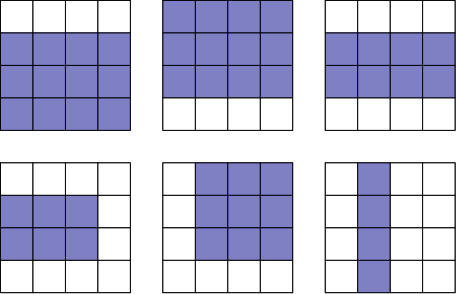

1. Ainda considerando o `ndarray` do exemplo anterior, encontre: A. O array com a soma dos elementos por linha. B. O array com a soma dos elementos por colunas. C. A soma e a média de todos os elementos.
1. Resolva os sistemas de equações lineares abaixo usando NumPy (https://numpy.org/doc/stable/reference/generated/numpy.linalg.solve.html):
   1. $2x + 3y = 4$

      $x - 5y = 2$
   2. $x + y = 0$

      $2x + y + z = 0$

      $4x + 3y + z = 0$
2. Considere os seguintes dados de coleta de amostras de pesos de pães (como no exemplo):

`arr_paes = np.array(["frances","italiano","sirio","frances","sirio"])`

```
arr_pesos = np.array([[3.0,2.8,10,3.0,3.23,3.0,2.8,3.0],
              [5.0,5.3,4.95,4.9,5.23,5.,5.,6.],
              [3.0,2.8,3.1,3.0,3.23,3.,3.,3.],
              [6.0,6.8,6.1,6.0,6.23,5.8,5.9,6.],
              [3.0,2.8,3.1,3.0,3.23,3.,3.1,3.]])
```

O controle de qualidade define que, se uma amostra têm variancia maior do que metade da média, existe algo errado com os dados (muita variabilidade), de forma que a amostra deve ser coletada novamente. Crie um código (usando indexação booleana) que retorne o pão (se existir algum) que precise de uma nova amostra coletada.

1. Ainda considerando os dados dos pães. A qualidade precisa saber a média dos pesos de todos os pães no primeiro e no último dia de coletas. Use fatiamentos e no máximo duas linhas para extrair as duas informações.

## 4.2 Pandas I

O pandas é um pacote essêncial para se realizar análise de dados, muito disso se dá pelas suas duas estruturas de dados principais, a `series` e o `Dataframe`, usados em quase todas as aplicações de mineração de dados. Utilizaremos a importação do pacote com a seguinte convenção:

```python
import pandas as pd
```

### 4.2.1 Series

Uma Serie é um objeto do tipo array unidimensional contendo uma sequência de valores (de tipos semelhantes aos do NumPy) e um array associado de rótulos (*labels*) de dados, chamado *índice*. A series mais simples é composta de um array de dados:

```python
ser1 = pd.Series([4,3,4,5])
print(ser1)
print(type(ser1))
```

```
0    4
1    3
2    4
3    5
dtype: int64
<class 'pandas.core.series.Series'>
```

Podemos acessar tanto os valores quanto os indices de uma Series pelos métodos `values` e `index`:

```python
print(ser1.values)
print(ser1.index)
```

```
[4 3 4 5]
RangeIndex(start=0, stop=4, step=1)
```

Note que o tipo de estrutura de dados do `values` é justamente um array NumPy:

```python
print(type(ser1.values))
```

```
<class 'numpy.ndarray'>
```

Podemos criar uma Series e alterar os valores de index para o que quisermos, considere:

```python
ser2 = pd.Series([1,2,3,4], index=["a","b","c","d"])
print(ser2)
```

```
a    1
b    2
c    3
d    4
dtype: int64
```

Podemos usar os valores dos indices para acessar e alterar os elementos:

```python
print(ser2["a"])

# Alterando o elemento
ser2["a"] = 999
print(ser2.values)
```

```
1
[999   2   3   4]
```

### 4.2.2 Dataframe

Um dataframe representa uma tabela de dados retangular e contém uma coleção ordenada de colunas, em que cada uma é uma Series e pode ter um tipo de dado diferente. O dataframe têm um índice tanto para as linhas quanto para as colunas. Existem diversas formas para se criar Dataframes (embora na maioria dos casos ele será criado automáticamente ao carregarmos dados externos), algumas delas são mostradas abaixo:

#### Criação de Dataframes

```python
# DataFrame a partir de um dicionário de listas: as chaves são os nomes das colunas e as listas os valores
dic1 = {"peça1":[1,2,3,4],
        "peça2":[5,2,3,5],
        "peça3":[2,3,4,3]}
dt1 = pd.DataFrame(dic1)
print(dt1)
```

```
   peça1  peça2  peça3
0      1      5      2
1      2      2      3
2      3      3      4
3      4      5      3
```

Os indices das linhas foram criados automaticamente no dataframe, porém poderiamos criá-los também:

```python
# DataFrame a partir de um dicionário de listas com indices criados
dic2 = {"peça1":[1,2,3,4],
        "peça2":[5,2,3,5],
        "peça3":[2,3,4,3]}
dt2 = pd.DataFrame(dic2, index=[3,4,5,6])
print(dt2)
```

```
   peça1  peça2  peça3
3      1      5      2
4      2      2      3
5      3      3      4
6      4      5      3
```

Podemos selecionar as colunas do DatFrame pela notação em colchetes com o nome da coluna:

```python
# Selecionando uma coluna
dt1["peça1"]

# Note que o tipo de dados da coluna é:
print("Tipo da coluna :", type(dt1["peça1"]))

# Assim, sabemos que a Series tem duas partes; values e index, e que values é um NumPy array, podemos extrair as colunas dos
# dataframes como arrays e usar tudo que já sabemos sobre o NumPy:
arr = dt1["peça1"].values
print(type(arr))

# Extraindo dados de um array normalmente
print("Soma :",arr.sum())
print("Maximo :",arr.max())
print("Mínimo :",arr.min())
```

```
Tipo da coluna : <class 'pandas.core.series.Series'>
<class 'numpy.ndarray'>
Soma : 10
Maximo : 4
Mínimo : 1
```

Também podemos acessar as linhas usando o método `loc`, que retorna uma **Series**. Neste caso acessamos os indices:

```python
print(dt1.loc[0])
```

```
peça1    1
peça2    5
peça3    2
Name: 0, dtype: int64
```

Neste caso o indice deve existir. Tentando acessar a linha de indice 0 de dt2, um erro ocorre, pois ao criarmos o DF alteramos os índices, e o 0 não foi incluido:

```python
print(dt2.loc[0])
```

[output not shown]

Ainda, podemos usar indices sequenciais inteiros para acessar as linhas (mesmo que as mesmas tenham outros nomes em seus indices) usando o método `iloc` (que também retorna uma **Series**:

```python
dt2.iloc[0]
```

[output not shown]

Usando o método `columns` obtemos um objeto do tipo Index com as colunas do DataFrame.

```python
type(dt1.columns)
```

Podemos adicionar uma nova coluna no DataFrame usando as chaves com o nome da coluna:

```python
# Todos os elementos da nova coluna são preenchidas com o valor 10
dt1["Nova coluna"] = 10
dt1
```

[output not shown]

Da mesma forma podemos remover colunas usando o método `del`.

```python
del dt1["peça1"]
dt1
```

[output not shown]

#### Ordenando

Podemos ordenar todo um dataframe com base nos dados de uma coluna usando a função `.sort_values()`, passando o argumento `by=` com o nome da coluna que queremos ordenar. Considerando o banco de dados das peças, o código abaixo ordena a dataframe de Peças pelos valores de peça2 (note que que os indices das linhas foram alterados):

```python
dt1.sort_values(by="peça2")
```

[output not shown]

#### Carregando dados em um DataFrame

A maior utilidade dos DataFrames é a manipulação de dados. Dessa forma, o Pandas contém inúmeras maneiras para se carregar dados externos, e a estrutura de dados padrão gerada é um Dataframe. Inicialmente, faremos a leitura de dados no formato .csv do próprio computador. Para isso usamos o método `pd.read_csv()`. Esse método possui diversos parametros (mais de 50!), porém os dois principais são: o caminho do arquivo a ser lido e o delimitador dos dados. Considere o exemplo abaixo que carrega os dados "e-shop clothing 2008.csv", contido na pasta Data.

```python
caminho = "G:\\Meu Drive\\Arquivos\\UFPR\\Disciplinas\\2 - Intro  Mineração de Dados\\Python\\Datasets\\e-shop clothing 2008.csv"
dt = pd.read_csv(caminho,sep = ";")
dt
```

Alguns repositórios de dados disponibilizam os mesmos diretamente da internet, de forma que podemos carregar os dados sem mesmo baixá-los no computador. Para isso só precisamos do URL dos dados. Por exemplo: https://raw.githubusercontent.com/cs109/2014_data/master/countries.csv. Lendo esses dados em um DataFrame temos:

```python
caminho_url = "https://raw.githubusercontent.com/cs109/2014_data/master/countries.csv"
dt_url = pd.read_csv(caminho_url, sep = ",")
dt_url
```

[output not shown]

Também podemos ler dados tabulares direto de uma planilha de excel com o método `read_excel`. OBS: Para isso o pandas requer a instalação do pacote `openpyxl`. Assim, abra um terminal e instale o pacote pelo *pip install*:

`pip install openpyxl`

```python
# Podemos usar a string pura do caminho (sem barras invertidas), usando a letra 'r' antes de começar o caminho
caminho_excel = r"G:\Meu Drive\Arquivos\UFPR\Disciplinas\2 - Intro  Mineração de Dados\Python\Datasets\db_addresses_lat_long.xlsx"
dt_excel = pd.read_excel(caminho_excel)
dt_excel
```

#### Exportando dados de um Dataframe

Podemos exportar os dados de um DataFrame usando o método `.to_csv()`, em seu modo mais simples com o único argumento do caminho do arquivo.

```python
caminho = r"G:\Meu Drive\Arquivos\UFPR\Disciplinas\Arquivo_exportado.csv"
dt1.to_csv(caminho)
```

```python
dt1
```

[output not shown]

Exportando dessa forma surgem 3 problemas (ou melhorias possíveis):

1. As índices das linhas foram exportados também.
2. O arquivo não fica tabulado ao abri-lo com o Excel.
3. Os nomes não estão com a acentuação correta.

Para melhorar a exportação usamos os seguintes argumentos:

1. `index = False`: Não exporta o índice das linhas.
2. `sep = ";"`: Adicionando o separador ';', os dados ficam tabulares no Excel.
3. `encoding = "utf-8-sig"`: Permite exportar acentos.

Assim, o código melhorado fica:

```python
caminho = r"G:\Meu Drive\Arquivos\UFPR\Disciplinas\Arquivo_exportado.csv"
dt1.to_csv(caminho, sep = ";", index = False, encoding = "utf-8-sig")
```

[output not shown]

Assim que carregamos um conjunto de dados, podemos obter algumas informações superficiais e rápidas sobre eles, por exemplo:

```python
#dt1.shape
#dt1.info()
dt1.describe()
```

[output not shown]

# Exercícios II

1. Considerando o conjunto de dados *MateriaisConstrução.xlsx*. Este conjunto contém dados referente a compra em uma loja de construção. Cada linha representa um pedido, sendo que as colunas contém os itens comprados e as células as quantidades adquiridas. Responda às seguintes questões:
   1. Quantos registros de compra existem?
   2. Quantos e quais os itens vendidos pela loja?
   3. Quais as médias de vendas dos itens?
   4. Qual é o item com a maior média de vendas?
   5. Qual é o item que está presente na maioria das compras? Em quantas?
1. Considere o conjunto de dados *Production_Data.csv*.Este conjunto contém dados de produção, a coluna `Case ID` indica as ordens de produção, uma ordem de produção passa por diversas atividades (`Activity`), portanto existem diversas linhas para cada `Case ID`. A coluna `Worker ID` indica o número de identificação do funcionário que realizou a atividade. `Qty Rejected` indica quantas peças foram perdidas na atividade executada naquela linha.`Start Timestamp` e `Complete Timestamp` indicam as datas e horas de inicio e fim de processamento das atividades. Reponda às seguintes questões:
   1. Quantos trabalhadores existem nesse db?
   2. Qual o total de peças rejeitadas no db?
   3. Quantas ordens de produção foram processados no total?
   4. Quais são as datas mais cedo e mais tarde de inicio de processamento de OPs?
   5. O db compreende um período de quantos dias de produção?
   6. Quais as médias de peças rejeitadas/dia e ordens de produção/dia no periodo todo?
   7. Quais as médias de peças rejeitadas/dia e ordens de produção/dia nos seguintes periodos:
      1. [2012/01/02,2012/02/01) -> janeiro
      2. [2012/02/01,2012/03/01) -> fevereiro
      3. [2012/03/01,2012/03/30] -> março
   8. Qual é o tempo médio, em minutos, de processamento da atividade *"Turning & Milling - Machine 4"*?